# SIR model with vaccination (SIRV): from demo to vignette

## Introduction

This vignette converts the `demo/sir_demo.R` workflow into a reproducible, narrative document for the **epiLabR** package. In addition to the original demo steps, it includes practical analysis extensions such as scenario comparison and epidemiological summary metrics.

## 1. Load the package

```r
library(epiLabR)
```

## 2. Define the SIRV model

We start from a model with four compartments:

- `S`: susceptible
- `I`: infectious
- `R`: recovered
- `V`: vaccinated

We also define one derived variable:

- `incidence = beta * S * I / N`, where `N = S + I + R + V`

```r
sirv_rhs <- function(time, state, parms) {
  with(as.list(c(state, parms)), {
    N <- S + I + R + V

    incidence <- beta * S * I / N

    dS <- -incidence - nu * S
    dI <-  incidence - gamma * I
    dR <-  gamma * I
    dV <-  nu * S

    list(
      c(dS, dI, dR, dV),
      incidence = incidence
    )
  })
}

SIRV_MODEL <- epi_model(
  name      = "SIRV",
  rhs       = sirv_rhs,
  par_names = c("beta", "gamma", "nu"),
  states    = c("S", "I", "R", "V"),
  derived   = "incidence",
  defaults  = c(beta = 0.3, gamma = 0.1, nu = 0.01)
)

SIRV_MODEL
```

```
#> <epi_model> SIRV
#>   States:   S, I, R, V
#>   Params:   beta, gamma, nu
#>   Derived:  incidence
#>   Inits:    (none defined)
#>   Defaults:
#>  beta gamma    nu
#>  0.30  0.10  0.01
#>   Equations (rhs):
#>     function (time, state, parms)
#>     {
#>         with(as.list(c(state, parms)), {
#>             N <- S + I + R + V
#>             incidence <- beta * S * I/N
#>             dS <- -incidence - nu * S
#>             dI <- incidence - gamma * I
#>             dR <- gamma * I
#>             dV <- nu * S
#>             list(c(dS, dI, dR, dV), incidence = incidence)
#>         })
#>     }
```

## 3. Default parameters and initial conditions

The model object can include built-in default parameters to make quick simulations easier.

```r
SIRV_MODEL$defaults
```

```
#>  beta gamma    nu
#>  0.30  0.10  0.01
```

```r
init <- c(S = 1e5, I = 10, R = 0, V = 0)
init
```

```
#>     S     I     R     V
#> 1e+05 1e+01 0e+00 0e+00
```

## 4. Baseline simulation

```r
sim_base <- simulate_epi(
  model = SIRV_MODEL,
  times = 0:200,
  parms = SIRV_MODEL$defaults,
  init  = init
)

summary(sim_base)
```

```
#> $model
#> <epi_model> SIRV
#>   States:   S, I, R, V
#>   Params:   beta, gamma, nu
#>   Derived:  incidence
#>   Inits:    (none defined)
#>   Defaults:
#>  beta gamma    nu
#>  0.30  0.10  0.01
#>   Equations (rhs):
#>     function (time, state, parms)
#>     {
#>         with(as.list(c(state, parms)), {
#>             N <- S + I + R + V
#>             incidence <- beta * S * I/N
#>             dS <- -incidence - nu * S
#>             dI <- incidence - gamma * I
#>             dR <- gamma * I
#>             dV <- nu * S
#>             list(c(dS, dI, dR, dV), incidence = incidence)
#>         })
#>     }
#>
#> $peak_I
#> [1] 7836.705
#>
#> $time_peak_I
#> [1] 62
#>
#> $total_infections
#> [1] 37318.21
#>
#> attr(,"class")
#> [1] "summary_sim_epi"
```

Now plot state trajectories and incidence.

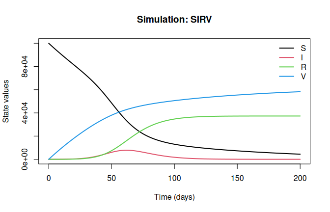

```r
plot(sim_base)
```

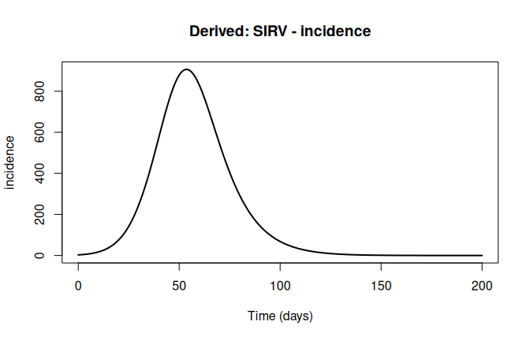

```r
plot(sim_base, what = "incidence")
```

## 5. Compare vaccination scenarios

One advantage of turning the demo into a vignette is easy scenario analysis. Here we compare three vaccination rates (`nu`).

```r
nu_values <- c(0, 0.01, 0.03)

sims <- lapply(nu_values, function(nu_i) {
  p <- SIRV_MODEL$defaults
  p["nu"] <- nu_i
  simulate_epi(SIRV_MODEL, times = 0:200, parms = p, init = init)
})

names(sims) <- paste0("nu=", nu_values)

# Peak prevalence of infectious individuals (I) by scenario
peak_prev <- sapply(sims, function(sim) {
  peak_prevalence(sim$states$I)
})
peak_prev
```

```
#>      nu=0     nu=0.01  nu=0.03
#> peak 30051.17 7836.705 197.883
#> time 51       63       37
```

```r
# Time to peak incidence by scenario
peak_time <- sapply(sims, function(sim) {
  time_to_peak(sim$derived$incidence, sim$derived$time)
})
peak_time
```

```
#>    nu=0 nu=0.01 nu=0.03
#>      43      54      28
```

In general, higher `nu` values tend to reduce epidemic peak prevalence and shrink the outbreak burden by moving a larger fraction of the population into `V` over time.

## 6. Register the model for app usage

If you want to use this model in the package registry, you can register it explicitly.

```r
register_epi_model(SIRV_MODEL)
list_models()
```

```
#> [1] "SEIR"  "SEIRS" "SI"    "SIR"   "SIR-V" "SIRS"  "SIRV"
```

> Note: if a model with the same name already exists, you may need to remove it first with `unregister_model("SIRV")`.

## 7. Next steps

- Adapt initial conditions for different population contexts.
- Add waning immunity (for example, a SIRVS-like extension).
- Use `run_epi_app()` for interactive scenario exploration.